# compile-regional-data

### Coho

#### Spawners

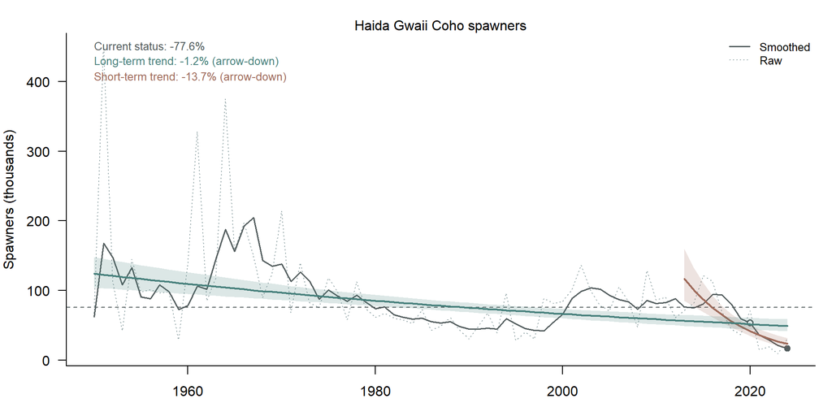

**Above:** Detailed status and trend metrics for Haida Gwaii Coho: short-term (3-generation) and long-term trend lines with 95% confidence intervals, the long-term average (dashed line), and current status relative to that average.

### Pink

#### Spawners

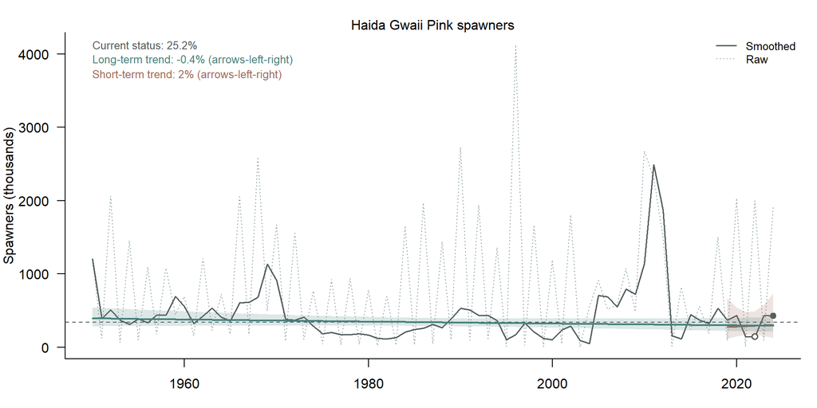

**Above:** Detailed status and trend metrics for Haida Gwaii Pink: short-term (3-generation) and long-term trend lines with 95% confidence intervals, the long-term average (dashed line), and current status relative to that average.

### Sockeye

#### Spawners

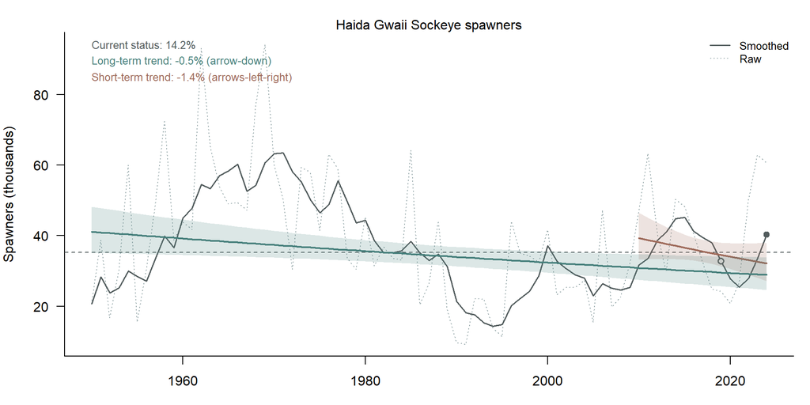

**Above:** Detailed status and trend metrics for Haida Gwaii Sockeye: short-term (3-generation) and long-term trend lines with 95% confidence intervals, the long-term average (dashed line), and current status relative to that average.

## 3.5 Nass

**Highlights**

### 3.5.1 All species table

**Below:** Summary of the three metrics for spawners and total return. For long-term trends and short-term trends, the percentage is the average annual change calculated over the respective time period. Grey values indicate the % change was not significantly different from zero (i.e., stable), red values indicate declining trends, and green values indicate increasing trends.

| Species | Variable | Current status | Long-term trend | Short-term trend | Current | Previous generation | Historical average | Generation length | Years of data | Span of data |
| --- | --- | --- | --- | --- | --- | --- | --- | --- | --- | --- |
| Chinook | Spawners | -2% | -0.4% | -0.6% | 16,543 | 10,702 | 16,881 | 5 | 51 | 1975-2025 |
| Chinook | Total return | -5.8% | 0% | -0.4% | 21,836 | 16,442 | 23,184 | 5 | 51 | 1975-2025 |
| Chum | Spawners | +92.6% | -1.1% | +19.5% | 85,056 | 60,503 | 44,168 | 4 | 76 | 1950-2025 |
| Chum | Total return | +95.7% | -2.8% | +19.2% | 99,764 | 71,087 | 50,982 | 4 | 34 | 1992-2025 |
| Coho | Spawners | +65.1% | +2.6% | +2.4% | 211,823 | 116,254 | 128,328 | 4 | 34 | 1992-2025 |
| Coho | Total return | +44.7% | +1.9% | -0.6% | 399,423 | 235,274 | 276,097 | 4 | 34 | 1992-2025 |
| Pink | Spawners | +438.8% | +2.3% | +33.8% | 1,388,898 | 1,023,237 | 257,778 | 2 | 76 | 1950-2025 |
| Pink | Total return | +175.6% | +0.4% | +34.6% | 1,550,765 | 1,133,442 | 562,628 | 2 | 34 | 1992-2025 |
| Sockeye | Spawners | +59.8% | +0.2% | +3.5% | 419,516 | 236,298 | 262,475 | 5 | 44 | 1982-2025 |
| Sockeye | Total return | -8.4% | -1.4% | -0.5% | 607,238 | 356,348 | 662,852 | 5 | 44 | 1982-2025 |

[output cut: 2 more lines]

### Chinook

#### Spawners

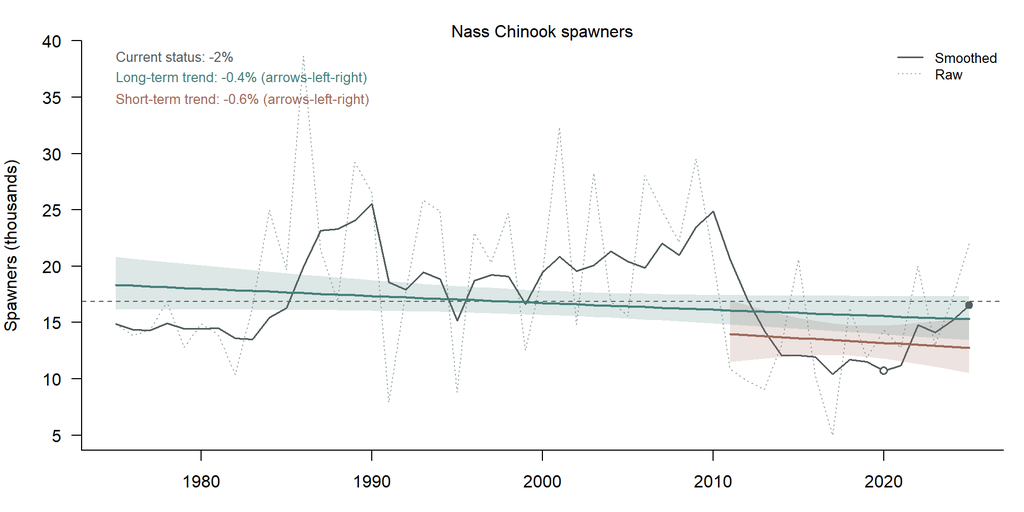

**Above:** Detailed status and trend metrics for Nass Chinook: short-term (3-generation) and long-term trend lines with 95% confidence intervals, the long-term average (dashed line), and current status relative to that average.

#### Total Return

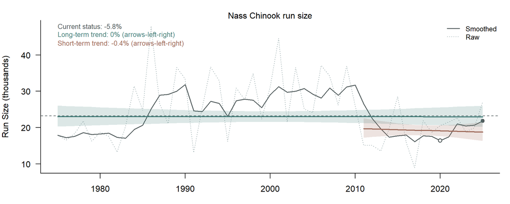

**Above:** Detailed status and trend metrics for Nass Chinook: short-term (3-generation) and long-term trend lines with 95% confidence intervals, the long-term average (dashed line), and current status relative to that average.

### Sockeye

#### Spawners

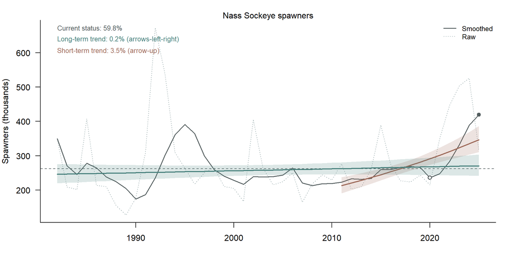

**Above:** Detailed status and trend metrics for Nass Sockeye: short-term (3-generation) and long-term trend lines with 95% confidence intervals, the long-term average (dashed line), and current status relative to that average.

#### Total Return

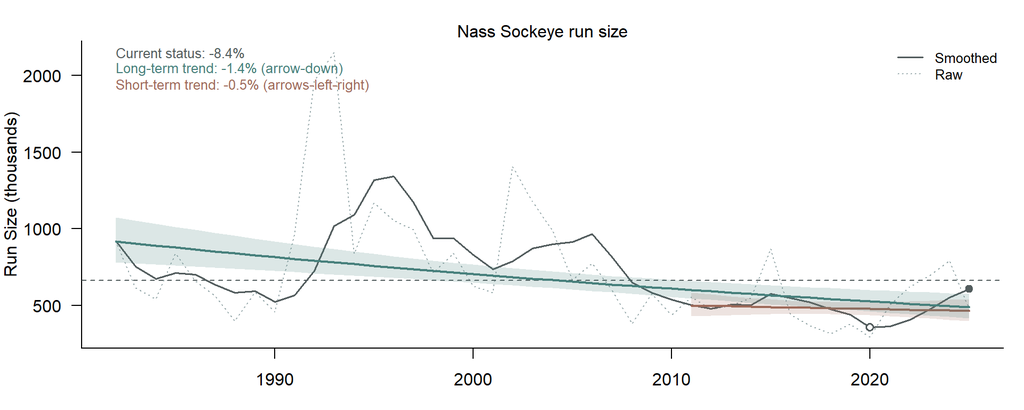

**Above:** Detailed status and trend metrics for Nass Sockeye: short-term (3-generation) and long-term trend lines with 95% confidence intervals, the long-term average (dashed line), and current status relative to that average.

### Coho

#### Spawners

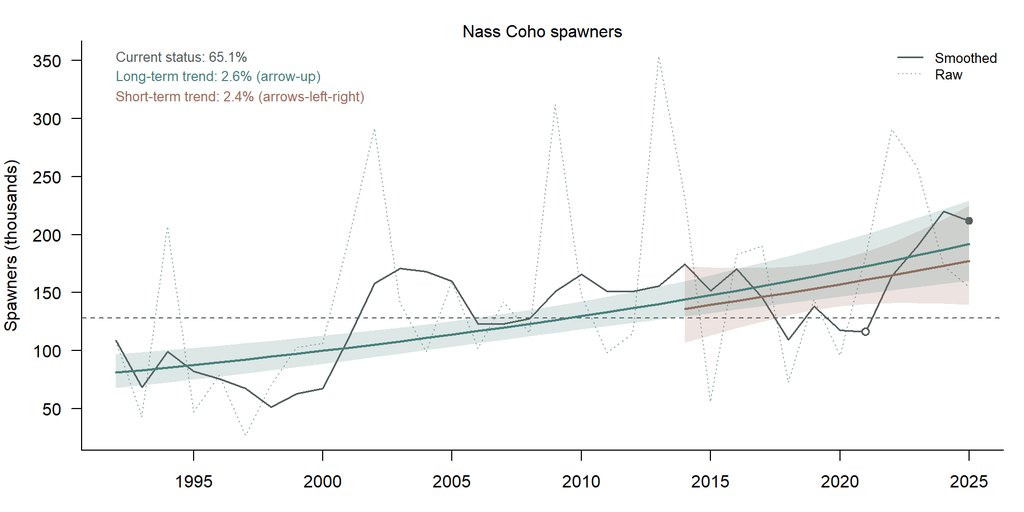

**Above:** Detailed status and trend metrics for Nass Coho: short-term (3-generation) and long-term trend lines with 95% confidence intervals, the long-term average (dashed line), and current status relative to that average.

#### Total Return

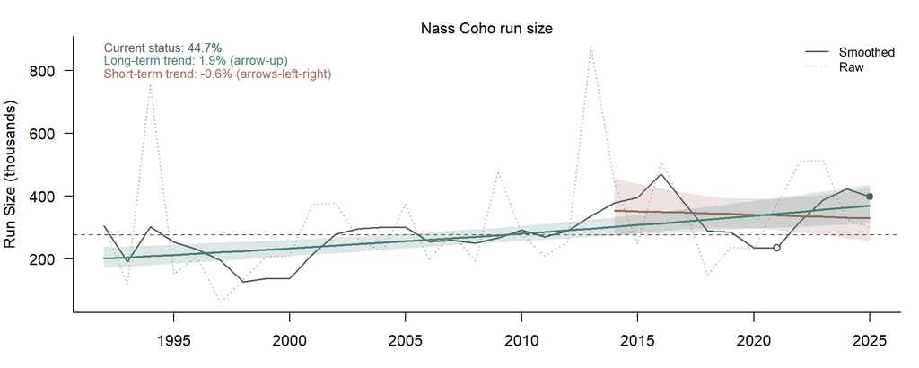

**Above:** Detailed status and trend metrics for Nass Coho: short-term (3-generation) and long-term trend lines with 95% confidence intervals, the long-term average (dashed line), and current status relative to that average.

### Pink

#### Spawners

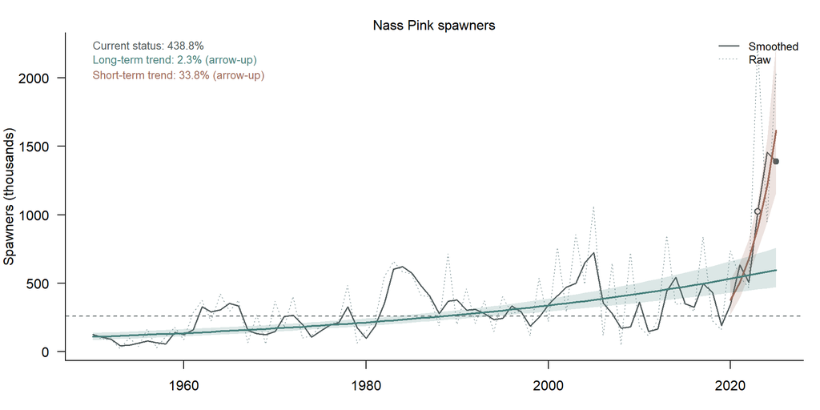

**Above:** Detailed status and trend metrics for Nass Pink: short-term (3-generation) and long-term trend lines with 95% confidence intervals, the long-term average (dashed line), and current status relative to that average.

#### Total Return

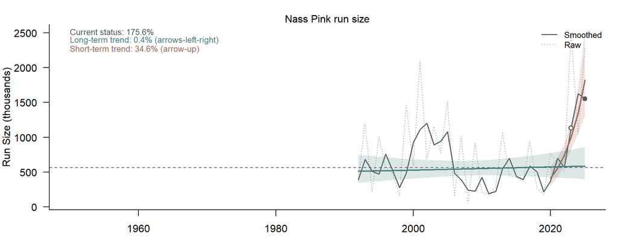

**Above:** Detailed status and trend metrics for Nass Pink: short-term (3-generation) and long-term trend lines with 95% confidence intervals, the long-term average (dashed line), and current status relative to that average.

### Chum

#### Spawners

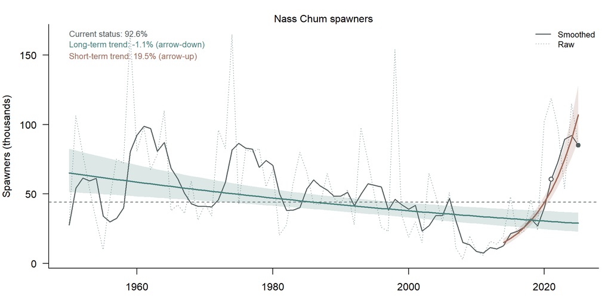

**Above:** Detailed status and trend metrics for Nass Chum: short-term (3-generation) and long-term trend lines with 95% confidence intervals, the long-term average (dashed line), and current status relative to that average.

#### Total Return

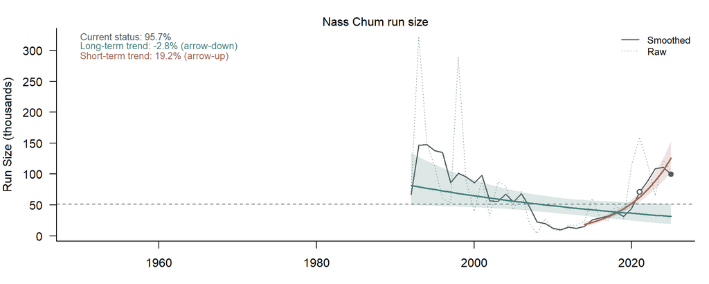

**Above:** Detailed status and trend metrics for Nass Chum: short-term (3-generation) and long-term trend lines with 95% confidence intervals, the long-term average (dashed line), and current status relative to that average.

### Steelhead

#### Spawners

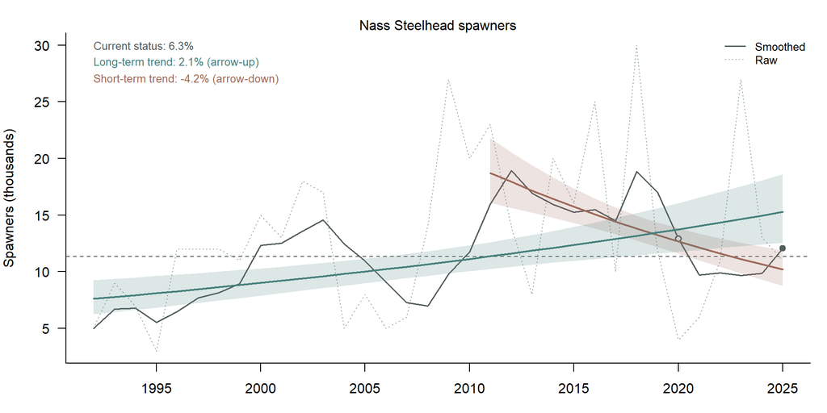

**Above:** Detailed status and trend metrics for Nass Steelhead: short-term (3-generation) and long-term trend lines with 95% confidence intervals, the long-term average (dashed line), and current status relative to that average.

#### Total Return

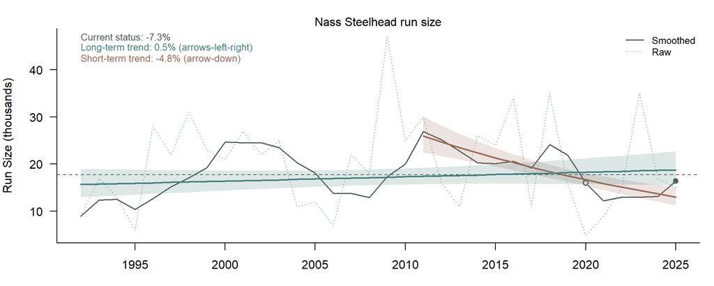

**Above:** Detailed status and trend metrics for Nass Steelhead: short-term (3-generation) and long-term trend lines with 95% confidence intervals, the long-term average (dashed line), and current status relative to that average.

## 3.6 Skeena

**Highlights**

### 3.6.1 All species table

**Below:** Summary of the three metrics for spawners and total return. For long-term trends and short-term trends, the percentage is the average annual change calculated over the respective time period. Grey values indicate the % change was not significantly different from zero (i.e., stable), red values indicate declining trends, and green values indicate increasing trends.

| Species | Variable | Current status | Long-term trend | Short-term trend | Current | Previous generation | Historical average | Generation length | Years of data | Span of data |
| --- | --- | --- | --- | --- | --- | --- | --- | --- | --- | --- |
| Chinook | Spawners | -45.1% | -1.7% | -6.5% | 24,708 | 29,812 | 45,036 | 6 | 42 | 1984-2025 |
| Chinook | Total return |  |  |  | ? | ? | ? | 6 | 0 |  |
| Chum | Spawners | -83.6% | -2.3% | -15.4% | 1,876 | 3,202 | 11,427 | 5 | 75 | 1950-2024 |
| Chum | Total return |  |  |  | ? | ? | ? | 5 | 0 |  |
| Coho | Spawners | -13% | -0.9% | -4.6% | 76,465 | 74,365 | 87,874 | 4 | 75 | 1950-2024 |
| Coho | Total return |  |  |  | ? | ? | ? | 4 | 0 |  |
| Pink | Spawners | +294% | -0.4% | +159.4% | 4,215,882 | 1,621,123 | 1,070,037 | 2 | 75 | 1950-2024 |
| Pink | Total return |  |  |  | ? | ? | ? | 2 | 0 |  |
| Sockeye | Spawners | +72.8% | +0.9% | +3.5% | 1,704,656 | 950,032 | 986,505 | 5 | 65 | 1960-2024 |
| Sockeye | Total return | +14% | +0.2% | +1.6% | 2,367,527 | 1,411,025 | 2,077,621 | 5 | 65 | 1960-2024 |

[output cut: 2 more lines]

### Chinook

#### Spawners

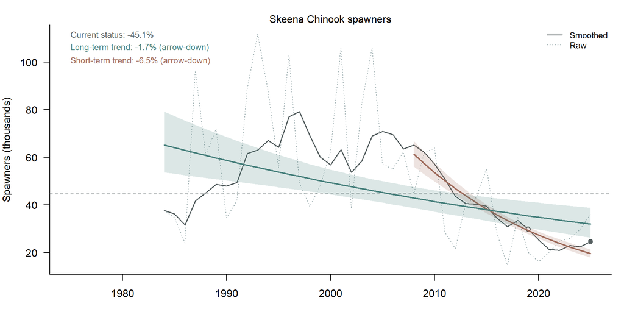

**Above:** Detailed status and trend metrics for Skeena Chinook: short-term (3-generation) and long-term trend lines with 95% confidence intervals, the long-term average (dashed line), and current status relative to that average.

### Sockeye

#### Spawners

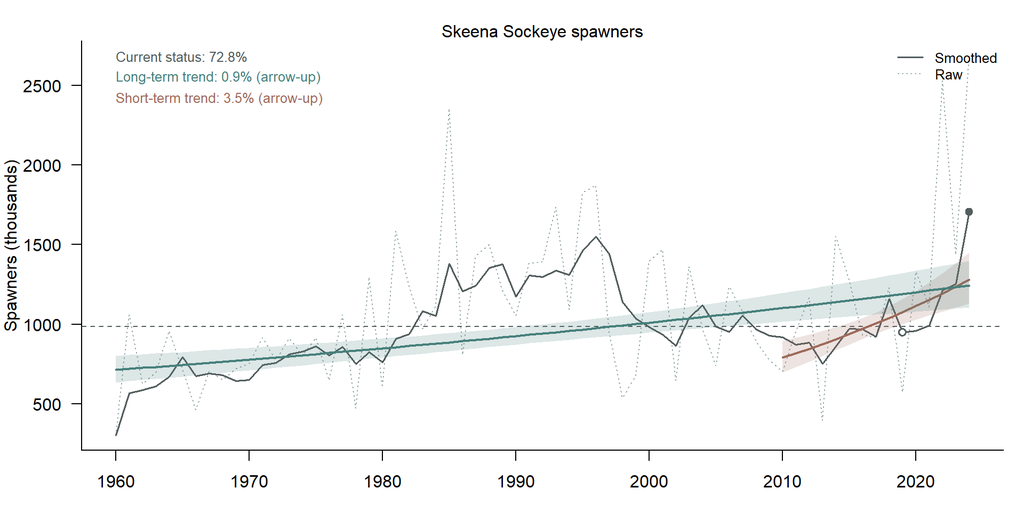

**Above:** Detailed status and trend metrics for Skeena Sockeye: short-term (3-generation) and long-term trend lines with 95% confidence intervals, the long-term average (dashed line), and current status relative to that average.

#### Total Return

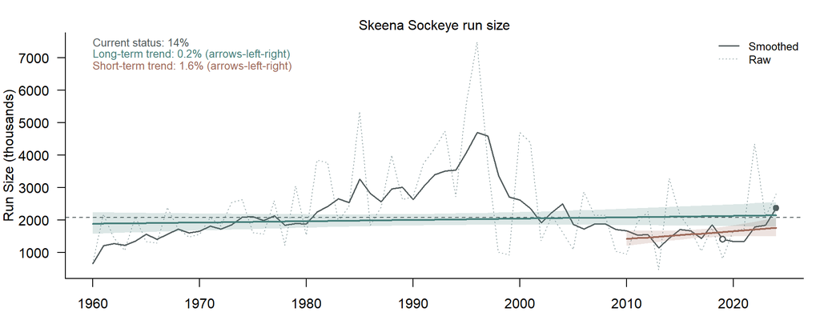

**Above:** Detailed status and trend metrics for Skeena Sockeye: short-term (3-generation) and long-term trend lines with 95% confidence intervals, the long-term average (dashed line), and current status relative to that average.

### Steelhead

#### Spawners

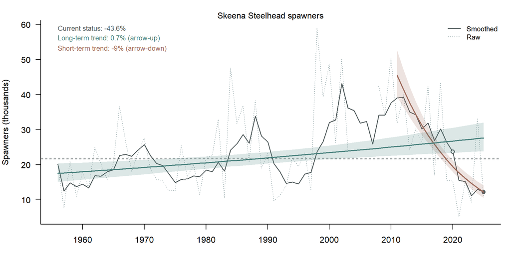

**Above:** Detailed status and trend metrics for Skeena Steelhead: short-term (3-generation) and long-term trend lines with 95% confidence intervals, the long-term average (dashed line), and current status relative to that average.

### Chum

#### Spawners

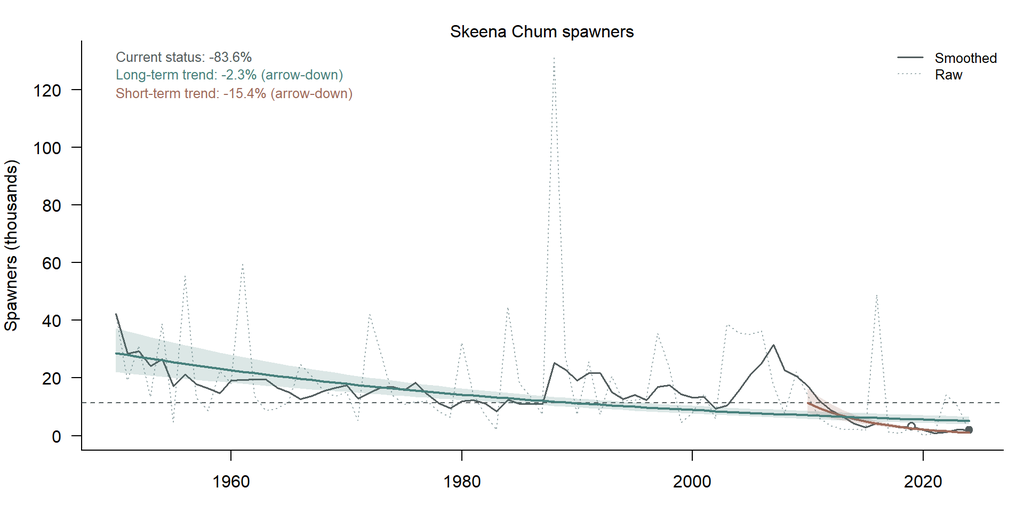

**Above:** Detailed status and trend metrics for Skeena Chum: short-term (3-generation) and long-term trend lines with 95% confidence intervals, the long-term average (dashed line), and current status relative to that average.

### Coho

#### Spawners

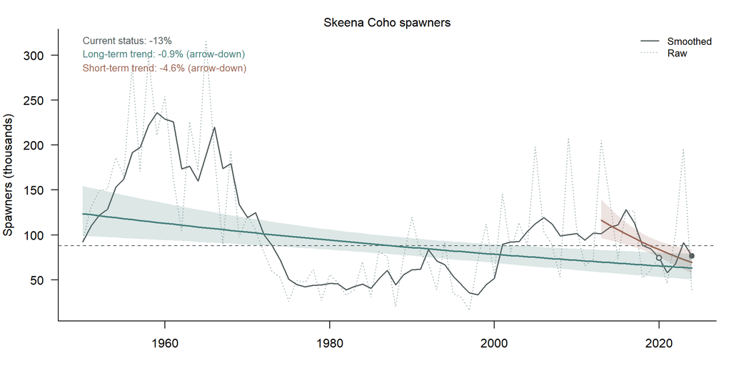

**Above:** Detailed status and trend metrics for Skeena Coho: short-term (3-generation) and long-term trend lines with 95% confidence intervals, the long-term average (dashed line), and current status relative to that average.

### Pink

#### Spawners

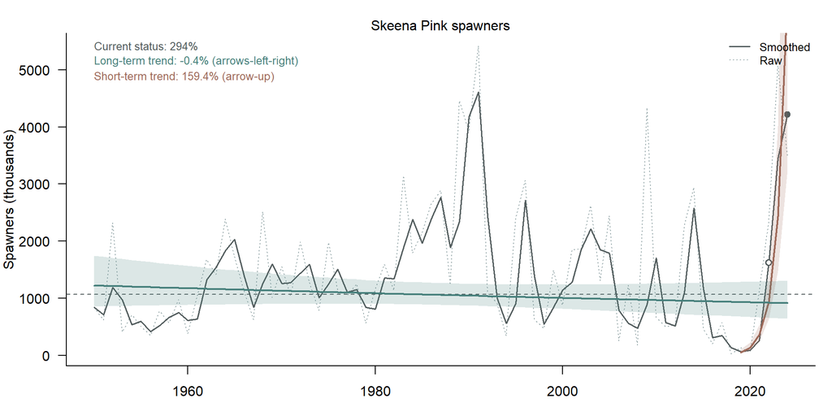

**Above:** Detailed status and trend metrics for Skeena Pink: short-term (3-generation) and long-term trend lines with 95% confidence intervals, the long-term average (dashed line), and current status relative to that average.

## 3.7 Central Coast

**Highlights**

### 3.7.1 All species table

**Below:** Summary of the three metrics for spawners and total return. For long-term trends and short-term trends, the percentage is the average annual change calculated over the respective time period. Grey values indicate the % change was not significantly different from zero (i.e., stable), red values indicate declining trends, and green values indicate increasing trends.

| Species | Variable | Current status | Long-term trend | Short-term trend | Current | Previous generation | Historical average | Generation length | Years of data | Span of data |
| --- | --- | --- | --- | --- | --- | --- | --- | --- | --- | --- |
| Chinook | Spawners | +7.2% | +1.1% | +2% | 17,899 | 18,882 | 16,696 | 5 | 51 | 1975-2025 |
| Chinook | Total return |  |  |  | ? | ? | ? | 5 | 0 |  |
| Chum | Spawners | -28.4% | -0.7% | -8.2% | 432,964 | 277,568 | 604,372 | 4 | 75 | 1950-2024 |
| Chum | Total return |  |  |  | ? | ? | ? | 4 | 0 |  |
| Coho | Spawners | -1.3% | -0.6% | -3.5% | 188,355 | 135,050 | 190,826 | 4 | 75 | 1950-2024 |
| Coho | Total return |  |  |  | ? | ? | ? | 4 | 0 |  |
| Pink | Spawners | +111.6% | +0.9% | +24.8% | 5,433,519 | 2,710,272 | 2,568,083 | 2 | 75 | 1950-2024 |
| Pink | Total return |  |  |  | ? | ? | ? | 2 | 0 |  |
| Sockeye | Spawners | +5.1% | -1.4% | +5.7% | 492,916 | 378,763 | 468,955 | 5 | 75 | 1950-2024 |
| Sockeye | Total return |  |  |  | ? | ? | ? | 5 | 0 |  |

[output cut: 2 more lines]

### Chinook

#### Spawners

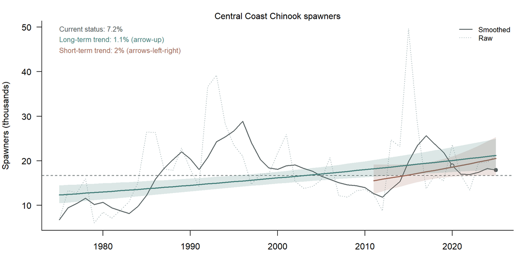

**Above:** Detailed status and trend metrics for Central Coast Chinook: short-term (3-generation) and long-term trend lines with 95% confidence intervals, the long-term average (dashed line), and current status relative to that average.

### Steelhead

#### Spawners

```
## No data for Central Coast Steelhead
```

### Chum

#### Spawners

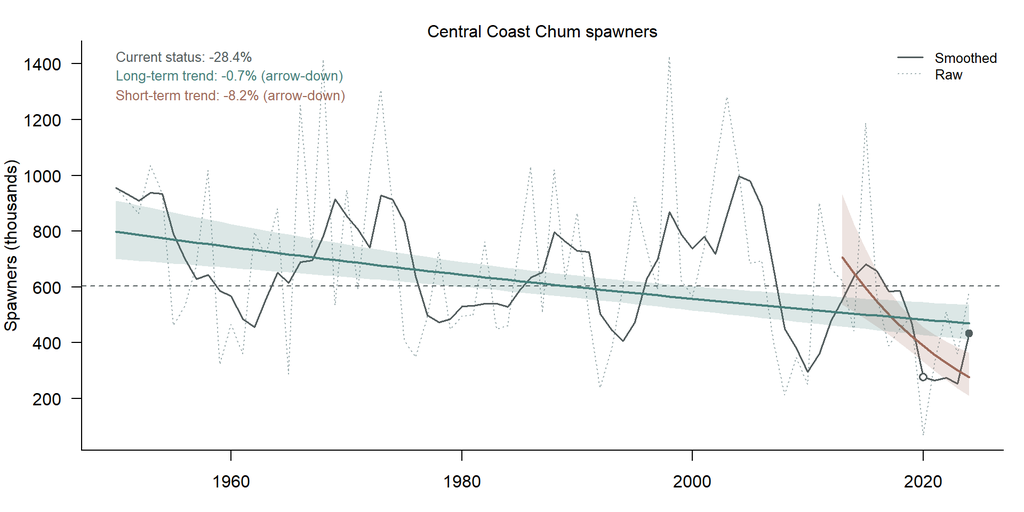

**Above:** Detailed status and trend metrics for Central Coast Chum: short-term (3-generation) and long-term trend lines with 95% confidence intervals, the long-term average (dashed line), and current status relative to that average.

### Coho

#### Spawners

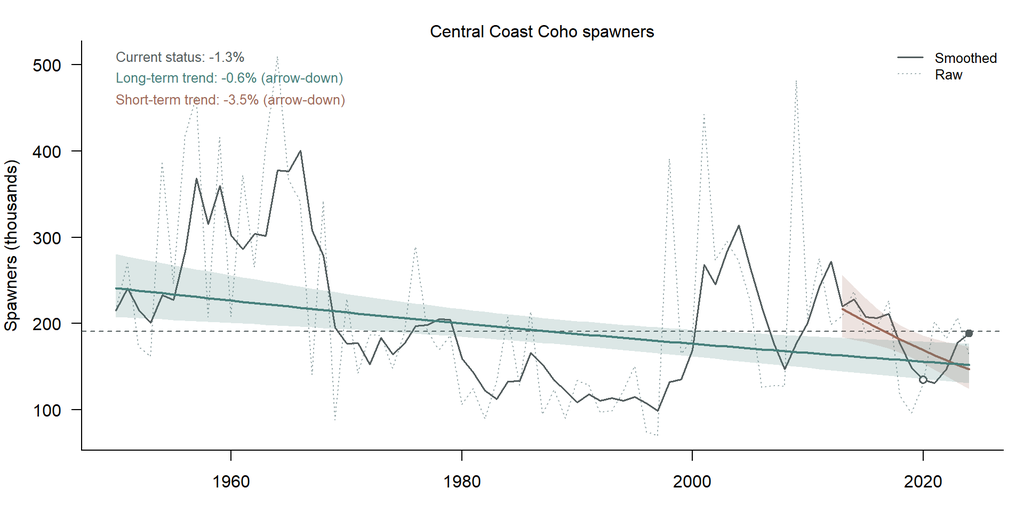

**Above:** Detailed status and trend metrics for Central Coast Coho: short-term (3-generation) and long-term trend lines with 95% confidence intervals, the long-term average (dashed line), and current status relative to that average.

### Pink

#### Spawners

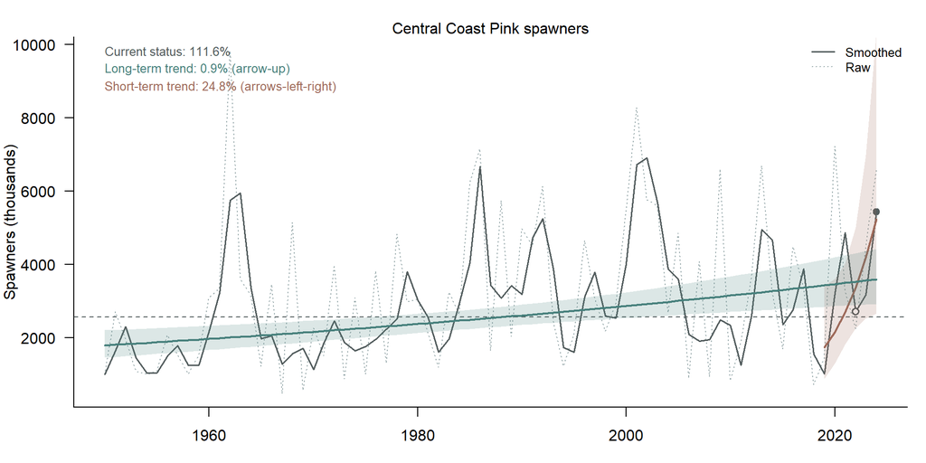

**Above:** Detailed status and trend metrics for Central Coast Pink: short-term (3-generation) and long-term trend lines with 95% confidence intervals, the long-term average (dashed line), and current status relative to that average.

### Sockeye

#### Spawners

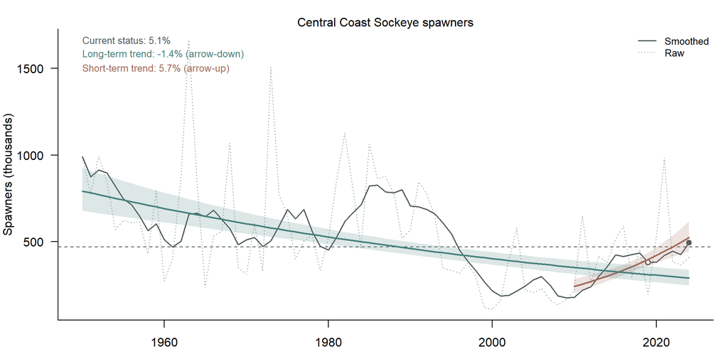

**Above:** Detailed status and trend metrics for Central Coast Sockeye: short-term (3-generation) and long-term trend lines with 95% confidence intervals, the long-term average (dashed line), and current status relative to that average.

## 3.8 East Vancouver Island & Mainland Inlets

**Highlights**

### 3.8.1 All species table

**Below:** Summary of the three metrics for spawners and total return. For long-term trends and short-term trends, the percentage is the average annual change calculated over the respective time period. Grey values indicate the % change was not significantly different from zero (i.e., stable), red values indicate declining trends, and green values indicate increasing trends.

| Species | Variable | Current status | Long-term trend | Short-term trend | Current | Previous generation | Historical average | Generation length | Years of data | Span of data |
| --- | --- | --- | --- | --- | --- | --- | --- | --- | --- | --- |
| Chinook | Spawners | +278.9% | +1.5% | +12.9% | 30,432 | 18,126 | 8,031 | 4 | 47 | 1979-2025 |
| Chinook | Total return | +259.8% | +1.7% | +12.8% | 34,517 | 20,459 | 9,592 | 4 | 51 | 1975-2025 |
| Chum | Spawners | -49.2% | +0.5% | -11.4% | 418,121 | 704,910 | 823,487 | 4 | 72 | 1953-2024 |
| Chum | Total return |  |  |  | ? | ? | ? | 4 | 0 |  |
| Coho | Spawners | +16.2% | -0.4% | +0.1% | 307,337 | 220,956 | 264,553 | 4 | 72 | 1953-2024 |
| Coho | Total return |  |  |  | ? | ? | ? | 4 | 0 |  |
| Pink | Spawners | +269.4% | +2% | +32.6% | 4,174,842 | 2,439,691 | 1,130,212 | 2 | 72 | 1953-2024 |
| Pink | Total return |  |  |  | ? | ? | ? | 2 | 0 |  |
| Sockeye | Spawners | -9.6% | -1% | +0.3% | 100,162 | 102,746 | 110,741 | 5 | 72 | 1953-2024 |
| Sockeye | Total return |  |  |  | ? | ? | ? | 5 | 0 |  |

[output cut: 2 more lines]

### Chinook

#### Spawners

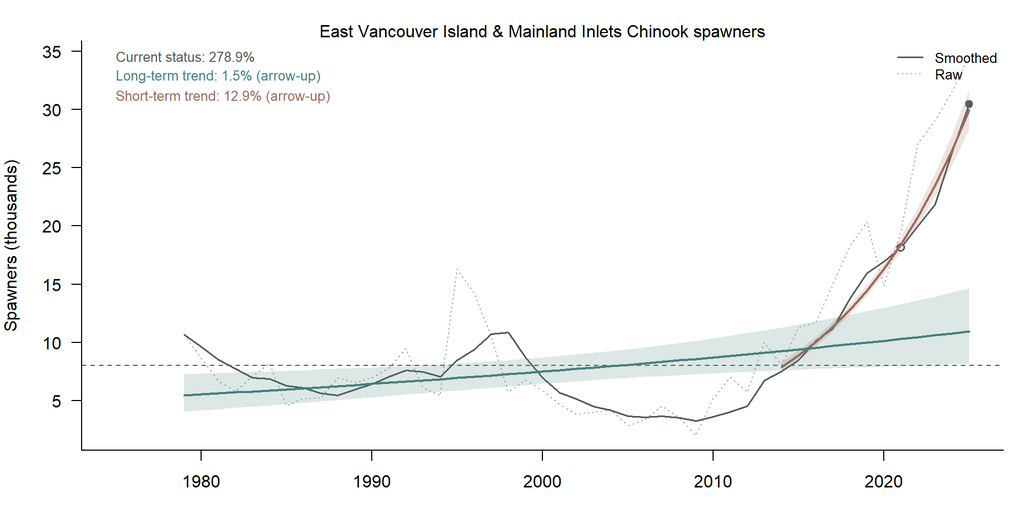

**Above:** Detailed status and trend metrics for East Vancouver Island & Mainland Inlets Chinook: short-term (3-generation) and long-term trend lines with 95% confidence intervals, the long-term average (dashed line), and current status relative to that average.

#### Total Return

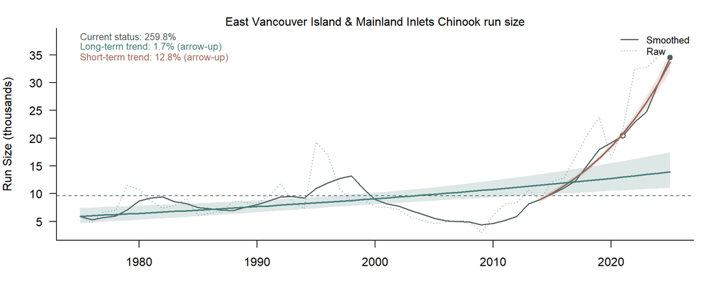

**Above:** Detailed status and trend metrics for East Vancouver Island & Mainland Inlets Chinook: short-term (3-generation) and long-term trend lines with 95% confidence intervals, the long-term average (dashed line), and current status relative to that average.

### Chum

#### Spawners

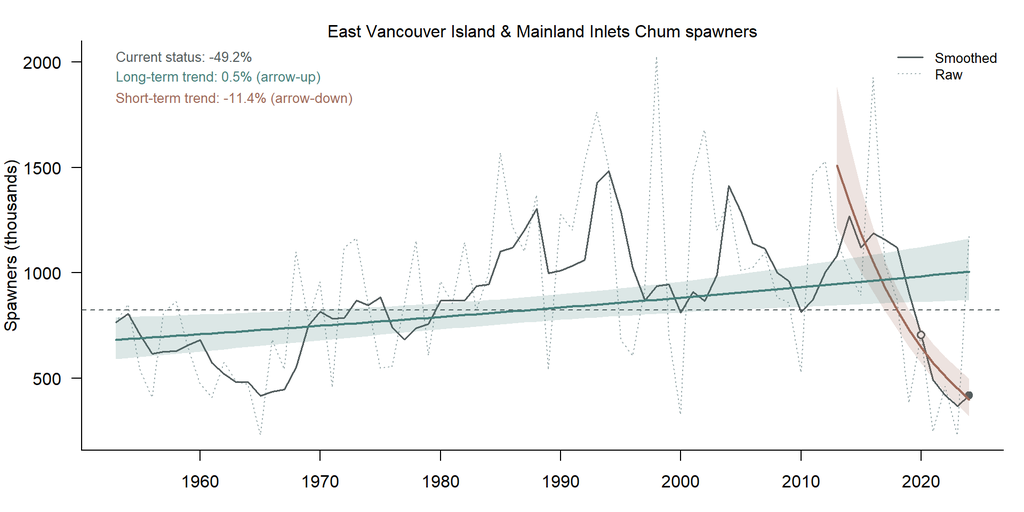

**Above:** Detailed status and trend metrics for East Vancouver Island & Mainland Inlets Chum: short-term (3-generation) and long-term trend lines with 95% confidence intervals, the long-term average (dashed line), and current status relative to that average.

### Coho

#### Spawners

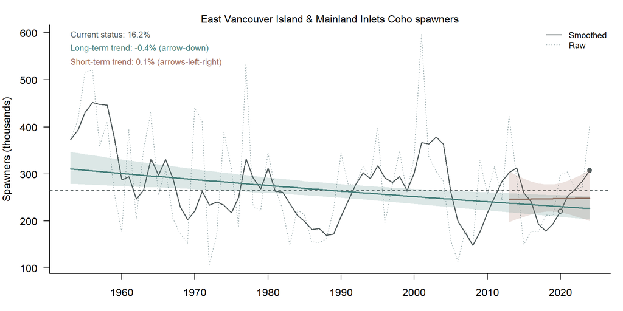

**Above:** Detailed status and trend metrics for East Vancouver Island & Mainland Inlets Coho: short-term (3-generation) and long-term trend lines with 95% confidence intervals, the long-term average (dashed line), and current status relative to that average.

### Pink

#### Spawners

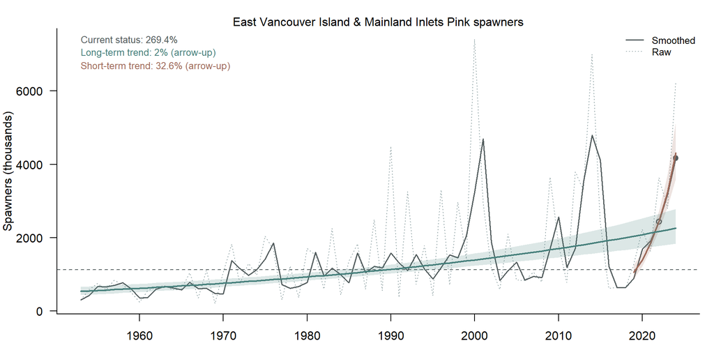

**Above:** Detailed status and trend metrics for East Vancouver Island & Mainland Inlets Pink: short-term (3-generation) and long-term trend lines with 95% confidence intervals, the long-term average (dashed line), and current status relative to that average.